# Global Standards for Federated Health Data Science: The GA4GH Approach

Team 3 (Rosetta) — Interoperability

Temitope Adeyelu, Emmanuel Oparaku, Victor Daniel, Aisosa Elizabeth Erhunmwunsee, Aseel Fadl

06 September 2026

# Abstract

Genomic and health research increasingly depends on data that cannot be moved, whether because of its size, the law where it is held, or the impossibility of full anonymisation. Where the data cannot travel, the analysis must travel instead, and that requires every participating compute system to read the same description of the job. The Global Alliance for Genomics and Health develops the international standards that make this possible, and ELIXIR, in Strategic Partnership with GA4GH since 2019, is applying them across European research infrastructure through the ELIXIR Cloud and AAI Driver Project.

This report does two things. It translates that standards work into plain language for a patient representative or public contributor, and it demonstrates the structure of one standard directly by constructing an example task document conforming to the GA4GH Task Execution Service specification. The document describes a synthetic three-step 16S rRNA microbiome analysis and validates against the published `tesTask` schema with no violations. Every factual claim is traced to the official page it came from.

The work is a structural example. It has not been run on a live service and involves no real data. We set out explicitly what schema validation establishes, which is that a document is correctly shaped, and what it cannot establish, which is whether the analysis it describes is correct.

# 1 Introduction and Background

## 1.1 The problem this work addresses

Genomic and health research increasingly depends on data that cannot easily be moved: too large to transfer, held under data-protection law where it sits, or impossible to anonymise fully. Where the data cannot travel, the analysis must travel instead, and that only works if every participating compute system can read the same description of the job.

The Global Alliance for Genomics and Health builds the international standards that make such a description possible. ELIXIR, Europe’s life-science research infrastructure, has worked with GA4GH since 2013, formalised as a Strategic Partnership announced in May 2019. ELIXIR Cloud and AAI, a GA4GH Driver Project, is building a federated compute network across ELIXIR’s national Nodes with the Task Execution Service at its core. Section 3.1 explains these ideas in full for a non-specialist reader.

## 1.2 Aims of this work

This report has two aims: to translate an international standards body’s technical work into material a patient representative could genuinely use, and to demonstrate understanding of the standard itself by constructing one example TES task document and validating it against the published schema.

The scope is bounded. We did not deploy a TES server, access real patient data, or submit anything to a production system. The document was built and checked locally against the official schema and public example tasks, and is a structural example only.

# 2 Methods

## 2.2 Constructing the TES task document

The scenario was chosen by the team rather than assigned. Emmanuel Oparaku, a medical doctor, proposed three candidates; the team read all three and voted, choosing 16S rRNA amplicon denoising because it was the more complex option and we wanted to challenge ourselves. Emmanuel Oparaku and Victor Daniel then built the document.

The pipeline is short by design: three executors run in sequence to import the reads, trim the primers and denoise with DADA2 through QIIME2. Only `executors` is required by the schema. We also populated `name`, `description`, `tags`, `inputs`, `outputs`, `resources` and `volumes`, because a document containing only `executors` would satisfy the schema and still be unusable. `inputs` and `outputs` are where federation happens, describing where data already sits and where results go. `resources` lets a receiving node decide whether it can place the job. `volumes` is what allows three steps to exist as one task. `tags` carry provenance. Each is optional to the schema but not to the task working. Table 1 sets out the fields that carried a real decision; Appendix B gives the reasoning in full.

## 2.3 Validation approach

The document was validated programmatically rather than by inspection. The schema came from the `main` branch of `ga4gh/task-execution-schemas`, `openapi/task_execution_service.openapi.yaml`, OpenAPI v3.0.1. Validation was run in Python using `jsonschema` and is reproduced in R below, so this report checks the document at knit time rather than reporting a result obtained elsewhere. Section 4.1 sets out what the check establishes.

## 2.4 Accessibility and audience-testing method

The explainer was read by two people outside the team, a family member with no background in health data and a colleague at work, each asked to explain it back in their own words. The family member did so accurately. The colleague suggested it would be easier to follow with a before and after, showing what happens without a GA4GH product and what changes once one is in place. In response we added the Temi example, which contrasts how her records would move without federation and with it.

# 3 Results

## 3.1 Plain-language explainer

> The following is reproduced as written for a public contributor or patient representative. The register is deliberately different from the rest of this report. This is the condensed version; the full explainer is at Appendix H.

Do you remember when all the gadgets you had came with their own charger and you had to carry 3-4 types of chargers with you when you left your home. Worst of all, if you forgot your charger at home, you couldn’t lend another person’s own because it was probably incompatible.

Technology companies also agreed that this wasn’t cost effective and the charging port and charger type of their phones was never the reason why customers chose them over a rival. So in 2009, fourteen of them committed to a shared USB connector, micro-USB, maintained by the USB Implementers Forum. The number of chargers in the market fell from more than thirty to three, and that agreement was what led to USB-C being the default charger for most gadgets.

That is what pre-competitive means. It refers to a collaborative environment where fierce business rivals choose to sit down at the same table to co-develop foundational technologies or research before competing on their final commercial products. Once the baseline was established, these companies went their separate ways and resumed competing for customer interests in their products.

Two words carry the rest of this. **Interoperability** is the standard based approach of enabling IT Systems to exchange data and share functionalities with minimal end user intervention. **Federation** is when two or more entities decide to collaborate and link their systems. This allows real-time access to information without giving up their independence, or the ownership and control of their assets. Interoperability can work without federation, but federation supercharges it and makes the entire ecosystem more efficient.

GA4GH stands for the Global Alliance for Genomics and Health and it’s a community whose mission is to speed up the progress in genomic research and human health by building standards, policies and tools for sharing genomic and health related data responsibly. It doesn’t hold data in a repository or connect research groups directly but uses interoperability and federation as key concepts in developing solutions for these data problems.

One of the hardest problems GA4GH tackles is how to work with data that can’t move because of its size, the data protection laws where the data exist and not being able to completely anonymise the data.

Imagine you want to bake a cake but the ingredients to do it are in the UK, the recipe is in Canada and the cake is needed in Canada. Instead of trying to get the ingredients to Canada, the recipe is sent to the UK, the cake is baked there and only the finished product is sent back to Canada. This is how GA4GH also works, they have come up with standards and tools that will allow researchers to send the analysis instructions to the location of the data and only the results of the analysis is sent back to the researchers.

Driver Projects are real world initiatives that implement and promote GA4GH products in their local networks. The driver project we will be talking about today is the ELIXIR Cloud and AAI. ELIXIR is an organisation that brings together life science resources across Europe. It has worked with GA4GH since 2013, formalised as a Strategic Partnership announced in May 2019.

Here is the kind of work this is being built for. Your flatmate is rushed to A&E with severe stomach pain. She is not responding to any antibiotic she has been given. To understand what is growing in her gut, a sample is taken and its genetic fingerprint is read. That fingerprint has to be compared against a far larger collection, held by a research group in another country. The collection cannot come to her. It is too large to move, governed by different data-sharing laws, and stored in a different format.

So the comparison goes to the collection instead. TES is the agreed way of handing over each small job. Simply put: WES orchestrates the entire workflow, and TES executes the tiny steps inside it. Think of a TES task document as a smaller recipe card. It is written in a format called JSON and consists of a few simple parts: **executors**, the steps and which software to use; **inputs**, the ingredients and where they currently sit; **outputs**, what the finished product is and where to drop it off; **resources**, how big a kitchen you need; **volumes**, the shared kitchen counter where steps pass things back and forth; and **tags**, the sticky label on the front of the card.

Our JSON is just a structural example using placeholder data, and checking a document against a TES specification only proves its shape is correct, not that the science inside it makes sense.

That is what GA4GH does. They write down the agreement. Organisations like ELIXIR build the tools that keep it. Nobody is forced to take part. It works for the exact same reason your phone charger works in your friend’s phone: enough people decided that solving a problem together once was infinitely better than trying to solve it separately forever.

## 3.2 The standards map

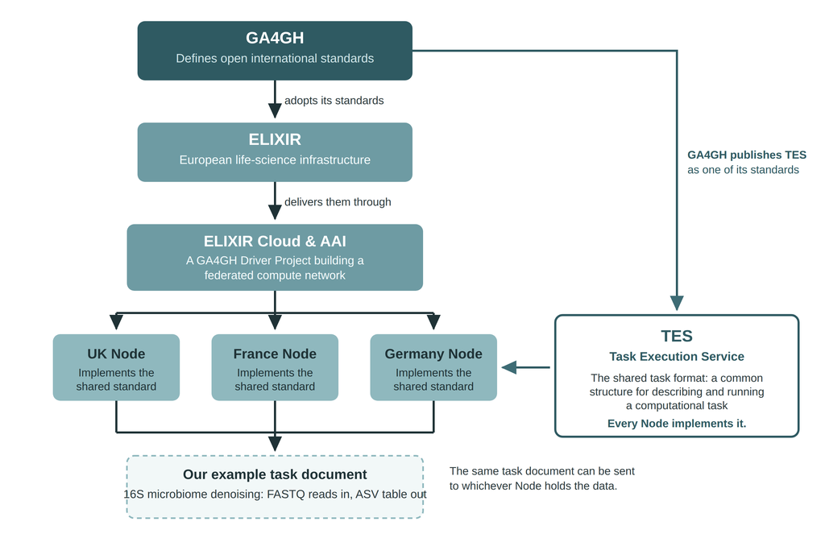

Figure 1. How GA4GH, ELIXIR, ELIXIR Cloud and AAI, national Nodes and the TES standard relate to one another.

Figure 1 shows the chain of responsibility rather than a technical architecture. GA4GH defines the standards and operates none of the infrastructure below it. ELIXIR adopts them and delivers them through ELIXIR Cloud and AAI, which is building the federated compute network. The national Nodes sit underneath, each implementing the shared standard for itself.

TES is drawn to the side rather than beneath any one Node. It is published by GA4GH and implemented by every Node, not produced by any single country. An earlier version of this diagram showed TES descending from one Node, which reversed the relationship the whole challenge rests on. Our example task document sits at the end of the chain and could be sent to whichever Node holds the relevant data.

## 3.3 The TES task document

The example describes a synthetic gut-microbiome scenario: a paired-end 16S rRNA amplicon pipeline in which three executors run in sequence to import the reads, trim the primers and denoise with DADA2 through QIIME2. It produces a feature table, the representative sequence for each amplicon sequence variant, and per-sample denoising statistics.

No real or patient data is involved. The input and output locations are placeholder addresses representing data held at a federated node. The full document is reproduced at Appendix A.

```r
# CODE CHUNK 2 — validate the task document against the official schema.
# Counts as one 150-word block.

validator <- jsonvalidate::json_validator(tes_schema, engine = "ajv")
result    <- validator(task_text, verbose = TRUE, greedy = TRUE)

result
```

```
#> [1] TRUE
```

The document validates against the `tesTask` schema with no violations. It is correctly shaped according to the published standard.

That is a narrower statement than it may appear, and Section 4.1 sets out what it does and does not establish.

Table 1. TES fields used in the example task, and why each value was chosen.

| Field | Value | Rationale |
| --- | --- | --- |
| inputs[0].type | DIRECTORY | Paired-end sequencing produces a forward and a reverse read file for the same sample. Both must be present together, so a single-file input cannot represent the data. |
| inputs[0].url | s3://… (placeholder) | Stands in for the idea that input and output locations describe where data already sits, which at a real node would be a different form of address entirely. |
| resources.cpu_cores / ram_gb | 4 / 16 | Denoising is more memory-hungry than it is parallelisable: it holds a great deal of data in memory while learning the error pattern. Memory, not cores, is the bottleneck. |
| resources.disk_gb | 20 | One sample and its intermediates come to a few gigabytes. Over-requesting makes a task harder to place on a smaller participating node for no benefit. |
| resources.preemptible | false | Denoising is a single uninterrupted run. An interrupted run would have to restart from the beginning. |
| volumes | /data/work | Without shared storage, step 2 could not find the file step 1 produced, and the pipeline would need three separate submissions rather than one task. |
| executors[].image | One image for all three steps | All three commands belong to the same software, so one QIIME2 image covers the whole pipeline. |

# 4 Discussion

## 4.1 What schema validation does and does not prove

Our task document passes every check the `tesTask` schema can make, and it is worth being precise about what that establishes. Validation confirms that the permitted fields are present and hold values of the right type. It cannot show that the commands are scientifically appropriate, that the container image exists, or that the task would succeed on a particular service.

The clearest illustration is internal to the document. The three executors connect only because file names written in one step were typed by hand to match those expected by the next, and the schema has no way of knowing whether they agree. A single typo would pass every check made here and surface only when a step failed to find its input at run time. Validation tells a reviewer that the document is correctly shaped; whether the logic inside it is correct still needs human review or a controlled test run.

## 4.2 TES within the wider GA4GH standards ecosystem

TES is one product among many, and alone it does little. A task has to come from somewhere, which is what WES provides by orchestrating a workflow and breaking it into tasks. It has to refer to data wherever that data sits, which is DRS. The tools and workflows themselves have to be shareable, which is TRS. And none of it runs unless the receiving institution can establish who is asking and what they are permitted to do, which is the work of GA4GH Passports and the authentication and authorisation infrastructure around them.

Interoperability is therefore a property of the stack rather than of any single standard, and adopting TES alone would buy an institution very little. This also cuts against a natural reading of our own work: having spent our time on one specification, it would be easy to present TES as the centre of GA4GH when it is one piece of a much larger set.

## 4.3 Limitations and scope boundaries

This work is a structural example. The task document has not been submitted to a live TES service, no real or patient data is involved, and the storage locations in it are placeholders. We validated against a schema extracted from the published specification rather than against a running implementation, so we cannot say whether a deployed server would accept the document as written.

A wider limitation applies beyond our example. Adopting a standard is a starting point. Organisations still have to implement compatible versions correctly, test the integrations, secure their systems, manage identities and permissions, and maintain the governance around all of it. A shared standard removes avoidable differences. It does not guarantee that two systems will work together, and implementation quality decides whether they do.

## 4.4 Generalisability and next steps

The problem is not confined to Europe. DARE UK funded TRE-FX under its first phase to demonstrate how analyses can be run across a federation of Trusted Research Environments, on the grounds that this “would enable timely analysis of data scattered across the UK to answer urgent questions”. That is the same problem shape TES addresses: valuable data held in separate places, under separate governance, which cannot simply be pooled. We should not overstate the connection, since we did not verify which technical standards TRE-FX adopted and make no claim that it uses GA4GH products.

Three things would extend this work. The task document could be submitted to a local or sandbox implementation such as Funnel or TESK, which would test the pipeline logic that schema validation cannot reach. The same treatment could be applied to a second GA4GH standard, Beacon or DUO. And the explainer would benefit from being read by a patient and public involvement group rather than by two individuals.

# 5 Conclusion

Five points carry the argument of this report.

GA4GH develops standards and policy frameworks. It is not a central patient database, and the organisations that hold data remain responsible for it.

Interoperability means different systems can understand and use shared information while remaining different underneath.

TES provides one agreed way of describing a single computational task, and is one standard among several rather than the whole of GA4GH.

Federated analysis allows compute to travel to controlled data environments instead of centralising the data itself.

A valid standardised document still requires sound governance, human review and testing. Our own example passes every check the schema can make and would still fail on a single mistyped filename, which is the most useful thing we learned.

# Appendix A: Full TES task document

```json
{
  "name": "16S rRNA amplicon denoising (QIIME2/DADA2)",
  "description": "Synthetic gut-microbiome scenario for HDR UK Team 3's GA4GH interoperability challenge. Imports paired-end 16S rRNA V3-V4 amplicon reads, trims primers, and denoises with DADA2 (via QIIME2) to produce a feature table and representative sequences. Demonstrates a federated task: compute is described here and dispatched to wherever the input data already resides, rather than moving the sequencing data itself.",
  "tags": {
    "project": "hdr-uk-team3-ga4gh-challenge",
    "workflow": "16s-denoising-demo",
    "data_domain": "gut-microbiome"
  },
  "inputs": [
    {
      "name": "raw_reads",
      "description": "Paired-end 16S rRNA V3-V4 FASTQ files in Casava demultiplexed format (one sample pair, gzip-compressed).",
      "url": "s3://federated-node-example/raw_reads/",
      "path": "/data/raw_reads",
      "type": "DIRECTORY"
    }
  ],
  "outputs": [
    {
      "name": "feature_table",
      "description": "DADA2 feature table (samples x amplicon sequence variants).",
      "url": "s3://federated-node-example/results/table.qza",
      "path": "/data/work/table.qza",
      "type": "FILE"
    },
    {
      "name": "representative_sequences",
      "description": "Representative sequence for each amplicon sequence variant.",
      "url": "s3://federated-node-example/results/rep-seqs.qza",
      "path": "/data/work/rep-seqs.qza",
      "type": "FILE"
    },
    {
      "name": "denoising_stats",
      "description": "Per-sample DADA2 denoising statistics (reads filtered, merged, chimera-checked).",
      "url": "s3://federated-node-example/results/denoising-stats.qza",
      "path": "/data/work/denoising-stats.qza",
      "type": "FILE"
    }
  ],
  "resources": {
    "cpu_cores": 4,
    "ram_gb": 16,
    "disk_gb": 20,
    "preemptible": false
  },
  "volumes": [
    "/data/work"
  ],
  "executors": [
    {
      "image": "quay.io/qiime2/amplicon:2024.2",
      "command": [
        "qiime", "tools", "import",
        "--type", "SampleData[PairedEndSequencesWithQuality]",
        "--input-path", "/data/raw_reads",
        "--input-format", "CasavaOneEightSingleLanePerSampleDirFmt",
        "--output-path", "/data/work/demux.qza"
      ],
      "workdir": "/data/work",
      "stdout": "/data/work/logs/01_import.stdout.log",
      "stderr": "/data/work/logs/01_import.stderr.log"
    },
    {
      "image": "quay.io/qiime2/amplicon:2024.2",
      "command": [
        "qiime", "cutadapt", "trim-paired",
        "--i-demultiplexed-sequences", "/data/work/demux.qza",
        "--p-front-f", "GTGYCAGCMGCCGCGGTAA",
        "--p-front-r", "GGACTACNVGGGTWTCTAAT",
        "--o-trimmed-sequences", "/data/work/trimmed.qza"
      ],
      "workdir": "/data/work",
      "stdout": "/data/work/logs/02_trim.stdout.log",
      "stderr": "/data/work/logs/02_trim.stderr.log"
    },
    {
      "image": "quay.io/qiime2/amplicon:2024.2",
      "command": [
        "qiime", "dada2", "denoise-paired",
        "--i-demultiplexed-seqs", "/data/work/trimmed.qza",
        "--p-trunc-len-f", "0",
        "--p-trunc-len-r", "0",
        "--p-n-threads", "0",
        "--o-table", "/data/work/table.qza",
        "--o-representative-sequences", "/data/work/rep-seqs.qza",
        "--o-denoising-stats", "/data/work/denoising-stats.qza"
      ],
      "workdir": "/data/work",
      "stdout": "/data/work/logs/03_dada2.stdout.log",
      "stderr": "/data/work/logs/03_dada2.stderr.log"
    }
  ]
}
```

# Appendix B: Extended explanatory note

**Companion document to:** `tes_task_16s_denoising.json`

**Standard:** GA4GH Task Execution Service (TES) API, v1.1.0

This appendix sets out the reasoning behind the example task document in full: what the pipeline does, how a TES task document is structured, why each field value was chosen, and how the document was validated. Section 3.3 of the main report gives the condensed version. Technical and biological terms used here are defined in the glossary at Appendix E.

## B.1 The pipeline, in plain terms

We’ve built this task document to describe one pipeline made of three steps, run in strict order. Each step takes in the previous step’s output. Nothing runs in parallel, and if one step fails, the ones after it don’t run at all.

**Step 1 — Import.** The raw sequencing files arrive in a standard format used by Illumina sequencing machines. This step converts them into QIIME2’s internal format so the rest of the pipeline can work with them.

**Step 2 — Trim primers.** The synthetic primer sequences used to target the 16S region are still attached to every read at this point. This step strips them off, since leaving them in would distort the denoising step that follows.

**Step 3 — Denoise.** The core analysis step. This is where real biological signal is separated from sequencing error and chimeras are removed, producing the final feature table and the list of ASVs.

What comes out the other end: a feature table (which ASVs, how many, per sample), the actual DNA sequence of each ASV, and a statistics file showing how many reads survived each stage. This is useful for sanity-checking that nothing went wrong along the way.

## B.2 The six ingredients of a TES task document

Before we get into specific values, it helps to know that every TES task document is built from the same six kinds of information, regardless of what analysis it describes:

| Ingredient | What it captures |
| --- | --- |
| Inputs | Which files the task needs, and where they currently live |
| Executors | Which commands run, in what order, using which software container |
| Outputs | Which result files get produced, and where they should be sent afterwards |
| Resources | How much computing power (processors, memory, disk space) the task needs |
| Volumes | Shared storage space that lets multiple steps in the same task pass files to each other |
| Tags | Optional labels for organising or tracking tasks (project name, workflow name, etc.) |

Everything in the next two sections walks through one of these six ingredients, filled in with a specific value for this scenario.

## B.3 Why we made the choices we did

### Why a directory, not a single file, as input

The import step needs more than one file: paired-end sequencing produces a forward read file and a reverse read file for the same sample, and both have to be present together for QIIME2 to correctly pair them up. A single-file input wouldn’t be able to represent that. A directory is the only way to hand over both files as one input.

### Why cloud storage addresses (s3://…) rather than a plain file path

We’re using these addresses as a stand-in (a legible example, not a real location) for the underlying idea in federated compute: input and output locations describe where the data is located, which could be a specific institution’s own storage rather than a single central repository. In a real ELIXIR Cloud & AAI deployment, this would likely be a different kind of address entirely (a GA4GH-specific data address, or a location local to the compute node).

### Why 4 processors and 16GB of memory

For a sense of scale: a typical laptop has somewhere between 8 and 16GB of RAM (memory) in total, and everyday tasks like browsing the web or writing a document use only a small slice of that, often under 4GB. Asking for 16GB for a single step, then, is asking for roughly as much memory as an entire ordinary laptop has, dedicated to this one task alone. That’s because the denoising step is more memory-hungry than it is parallelisable: it needs to hold a lot of data in memory while learning the sequencing error pattern, more than it needs many processors working simultaneously. The task document explicitly tells the software to use every processor it’s given, so the allocation isn’t wasted, but memory is the real bottleneck this task is built around.

### Why 20GB of disk space

A single sample’s raw files and all the intermediate results generated along the way realistically add up to a few gigabytes at most. 20GB leaves comfortable headroom without asking for far more than the task will ever use. Over-requesting matters in a federated setting, since a task asking for more space than it needs can be harder to place on a smaller participating computer for no real benefit.

### Why a shared storage volume is necessary

Without it, each of the three steps would run in total isolation and step 2 would have no way to find the file step 1 just created. Declaring shared storage is what allows a multi-step pipeline to exist as a single task document, rather than needing three separate submissions.

### An important limitation: passing schema validation doesn’t mean the pipeline is correct

The three steps connect to each other because the file names used in step 1’s output and step 2’s input were typed to match, by hand. The official rulebook (the schema) only checks that each field is present and of the right type. It has no way of knowing whether a file name one step produces is actually the same file name the next step expects. A typo in one of these matching names would still pass every schema check, and would only be caught when the task was actually run and a step failed to find its expected input. This is worth keeping in mind for anyone reviewing the document: passing validation confirms the file is correctly shaped, not that its internal logic is correct; that still needs a human check, or an actual test run.

## B.4 Technical reference (for anyone reading the JSON directly)

This table maps the plain-language points above to their exact field names in the file, for reference.

| Field | Value chosen | Why |
| --- | --- | --- |
| `name` / `description` | Descriptive, human-readable | Documents intent for anyone reviewing the task outside the JSON |
| `tags` | `project`, `workflow`, `data_domain` keys | Optional metadata, used here for provenance tracking |
| `inputs[0].type` | `DIRECTORY` | The import step needs a folder of files, not a single file |
| `inputs[0].url` | `s3://...` | Represents the data’s location at the federated node (see Section B.3) |
| `outputs[]` | Three `.qza` result files, each with a `path` and `url` | `path` is where the file is written inside the container; `url` is where it’s uploaded to afterwards |
| `resources.cpu_cores` / `ram_gb` | 4 / 16 | See “processors and memory” rationale in Section B.3 |
| `resources.disk_gb` | 20 | See “disk space” rationale in Section B.3 |
| `resources.preemptible` | `false` | Denoising is a single uninterrupted run; an interrupted run would need to restart from scratch |
| `volumes` | `/data/work` | Shared storage letting the three steps pass files to each other (see Section B.3) |
| `executors[].image` | Same container image for all three steps | All three commands belong to the same software (QIIME2), so one image covers the whole pipeline |
| `executors[].stdout` / `stderr` | Per-step log files | Keeps each step’s output separately inspectable if something goes wrong |

## B.5 Validation statement

We checked this document programmatically against the official TES rulebook (the `tesTask` schema), extracted directly from GA4GH’s published specification (v1.1.0, main branch of the `task-execution-schemas` repository: https://raw.githubusercontent.com/ga4gh/task-execution-schemas/refs/heads/main/openapi/task_execution_service.openapi.yaml). No violations were found. The file is correctly shaped according to the official standard. As noted in Section B.3, this confirms the document’s structure, not the correctness of the pipeline logic it describes.

# Appendix C: Frequently asked questions

The questions are grouped by audience. Part A addresses questions likely to be asked by patients, public contributors and other general readers. Part B addresses questions likely to be raised by researchers, health professionals, data specialists and technical stakeholders.

## Part A — Questions from patients, public contributors and general readers

These questions focus on what the standards mean for ordinary people, including privacy, trust and possible public benefit.

### Q1. What is GA4GH?

The Global Alliance for Genomics and Health (GA4GH) is an international, not-for-profit alliance that develops technical standards and policy frameworks for the responsible use of genomic and related health data. It does not operate as a patient database. Its role is to help organisations use compatible approaches so that authorised research can work across institutional and national boundaries.

**Key takeaway.** GA4GH creates shared standards and policy frameworks. It does not collect everyone’s health records.

### Q2. Why do researchers need international standards?

Hospitals, universities and research centres may use different software, data formats and computing platforms. Without shared standards, every connection may require a separate custom solution. International standards provide an agreed structure that reduces unnecessary incompatibility and makes tools easier to reuse across organisations.

**Key takeaway.** Shared standards give different organisations a common foundation for working together.

### Q3. What does “interoperability” mean?

Interoperability means that different systems can exchange information or instructions and use them correctly. It does not mean that every organisation must buy the same software. Systems can remain different underneath while agreeing on how requests and responses are described, similar to people using a shared language to communicate.

**Key takeaway.** Different systems can remain different and still understand one another.

### Q4. Does GA4GH collect, store or automatically share my health data?

No. GA4GH develops standards and policy frameworks; it does not hold a central collection of everyone’s medical or genomic records. Organisations that collect or steward data remain responsible for deciding how those data are stored, protected and accessed under applicable governance and law.

**Key takeaway.** GA4GH develops the rules and tools; data-holding organisations remain responsible for the data.

### Q5. Does TES move or expose patient data?

TES specifies how a computational task is described and executed. It is not a patient-data sharing agreement and does not automatically grant access to data. Data access, consent, security and governance remain the responsibility of the organisations operating the infrastructure. A federated design may allow analysis to be sent to controlled data locations instead of centralising sensitive source data.

**Key takeaway.** A technical standard does not replace privacy, security or access-control decisions.

### Q6. How could standards like these benefit patients and the public?

Shared standards can make research tools more reusable and help authorised teams collaborate across institutions. This may reduce duplicated technical work and support larger or more diverse research efforts. However, public benefit depends on responsible governance, meaningful security, appropriate access controls and high-quality implementation, not on the existence of a standard alone.

**Key takeaway.** Standards can enable better collaboration, but trust and governance remain essential.

## Part B — Questions from researchers, health professionals and technical stakeholders

These questions focus on implementation, the role of ELIXIR and the structure of a TES task.

### Q7. What is ELIXIR, and why is it relevant to this project?

ELIXIR is a European life-science research infrastructure. ELIXIR Cloud and AAI is recognised by GA4GH as a Driver Project developing a standards-compliant federated computing environment across European Nodes. It provides a real example of GA4GH standards being applied across organisational and national infrastructure.

**Key takeaway.** ELIXIR demonstrates how GA4GH standards can be put into practice in European research infrastructure.

### Q8. What is TES, and how is it different from WES?

The Task Execution Service (TES) is a GA4GH standard for describing, submitting and monitoring individual computational tasks. The Workflow Execution Service (WES) addresses complete workflows made up of connected analysis steps. In simple terms, TES focuses on a task to be executed, while WES coordinates a broader workflow that may involve multiple tasks.

**Key takeaway.** TES describes individual tasks; WES manages complete workflows.

### Q9. What information does a TES task document contain?

A TES task document can name and describe the task, identify inputs and outputs, request computing resources, declare shared volumes, add metadata tags and list one or more executors. In the team’s synthetic 16S example, three executors run sequentially to import reads, trim primers and perform denoising.

**Key takeaway.** A TES task document brings the task’s instructions, files and resource needs into one structured request.

### Q10. What does federated computing mean in this project?

Federated computing means that participating organisations retain control of their own infrastructure while agreeing on ways to request and run analysis across the network. In the team example, the task description is dispatched to the location where the input data are assumed to reside, rather than requiring all source data to be copied into one central repository.

**Key takeaway.** The analysis can travel to controlled data environments rather than all source data travelling to one place.

# Appendix D: Source log

Every substantive factual claim in this report, and the specific page it came from. All sources are official GA4GH or ELIXIR publications, or the team’s own files. All web sources accessed 19 August 2026.

## D.1 Sources

| Key | Source | URL |
| --- | --- | --- |
| S1 | GA4GH, “About us” | https://www.ga4gh.org/about-us/ |
| S2 | GA4GH Driver Projects, “ELIXIR Cloud and AAI for Human Data” | https://www.ga4gh.org/driver_project/elixir-cloud-and-aai-for-human-data/ |
| S3 | GA4GH news, “ELIXIR and GA4GH expand collaboration”, 2 May 2019 | https://www.ga4gh.org/news/elixir-and-ga4gh-expand-collaboration/ |
| S4 | GA4GH product page, “Task Execution Service (TES)” | https://www.ga4gh.org/product/task-execution-service-tes/ |
| S5 | GA4GH product page, “Workflow Execution Service (WES)” | https://www.ga4gh.org/product/workflow-execution-service-wes/ |
| S6 | GA4GH, `task-execution-schemas` repository | https://github.com/ga4gh/task-execution-schemas |
| S7 | ELIXIR Cloud and AAI documentation hub | https://elixir-cloud-aai.github.io/ |
| S8 | Team files: `tes_task_16s_denoising.json`, `tesTask.schema.json` | Supplied with this submission |
| S9 | DARE UK, “TRE-FX: Delivering a federated network of trusted research environments to enable safe data analytics” | https://dareuk.org.uk/how-we-work/previous-activities/dare-uk-phase-1-driver-projects/tre-fx-delivering-a-federated-network-of-trusted-research-environments-to-enable-safe-data-analytics/ |

## D.2 Claims

[output not shown]

## D.3 Claims not attributable to a single source

These are stated in the report but are not lifted from one page. They are either reasoning from two sources, or general explanation. Flagged here so a reviewer can see the difference.

| Claim | Where it appears | Basis |
| --- | --- | --- |
| TES describes individual tasks while WES manages complete workflows | Appendix C, Q8 | Neither product page compares the two directly. The contrast is drawn from S4 and S5 read together. |
| Definitions of interoperability, standard, specification and schema | Appendix C, Q3; Appendix E | Written by the team as plain-language explanation, not quoted from GA4GH |
| Rationale for the CPU, memory and disk values in the example task | Appendix B.3 | Team’s own reasoning about the QIIME2 and DADA2 pipeline, not a GA4GH claim |
| Schema validation confirms structure but not scientific or operational correctness | Section 4.1; Appendix B.3; Appendix F | Follows from what a JSON schema can check. Not asserted by GA4GH documentation. |

# Appendix E: Glossary

Definitions are written for this project’s context. The “Think of it like…” column is an analogy, not a technical definition.

## E.1 Standards, governance and computing terms

[output not shown]

## E.2 Terms specific to the 16S example

These terms relate to the synthetic gut-microbiome scenario used in the example task document. They are not part of the GA4GH standards vocabulary.

[output not shown]

# Appendix F: Myth versus fact

| Myth | Fact |
| --- | --- |
| GA4GH stores everyone’s genomic or health records. | GA4GH develops standards and policy frameworks. Data remain with the organisations that collect or steward them. |
| Using TES automatically gives a researcher permission to access data. | TES describes a computational task. Access permission must be managed separately through governance, authentication and authorisation. |
| A federated system means no information ever moves. | Federation can reduce the need to centralise source data, but tasks, approved outputs, logs or other permitted information may still move according to the system’s design and governance. |
| Passing schema validation proves that an analysis is scientifically correct. | Schema validation checks structure and data types. Scientific logic, paths, software behaviour and operational suitability still require review and testing. |
| Standards guarantee that every implementation will interoperate perfectly. | Standards create a common foundation, but implementation quality, version compatibility, security and testing still matter. |

# Appendix G: Reproducibility

To reproduce this report, unzip the submission and keep all files in one folder: `Team3_GA4GH_Report.Rmd`, `report_styles.css`, `tes_task_16s_denoising.json`, `tesTask.schema.json` and `Team3_standards_map_v2.png`.

It requires R with `jsonlite`, `jsonvalidate`, `knitr` and `kableExtra` installed, and pandoc, which RStudio provides. Open the `.Rmd` in a fresh R session and knit. No paths need editing: they are resolved relative to the `.Rmd` itself.

The table below is generated at knit time and reports whether each expected file was found, so a missing file is stated plainly rather than causing an obscure failure further down.

| File | Present |
| --- | --- |
| /Users/temit/Downloads/Team3_Submision/tes_task_16s_denoising.json | TRUE |
| /Users/temit/Downloads/Team3_Submision/tesTask.schema.json | TRUE |
| /Users/temit/Downloads/Team3_Submision/Team3_standards_map_v2.png | TRUE |

# Appendix H: Full plain-language explainer

To understand GA4GH, what they do and practically any other concept in this project, you must first understand what these two words mean: Interoperability and Federation.

Before we get into these two though, we need a bit of shared vocabulary. Four words come up constantly in this space and they are easy to mix up: standard, specification, implementation and pre-competitive. Let us build them first. Using something you have almost certainly held in your hand this week.

Do you remember when all the gadgets you had came with their own charger and you had to carry 3-4 types of chargers with you when you left your home. Worst of all, if you forgot your charger at home, you couldn’t lend another person’s own because it was probably incompatible.

Technology companies also agreed that this wasn’t cost effective and the charging port and charger type of their phones was never the reason why customers chose them over a rival. They also had pressure from the European Commission to sort out the dilemma.

So in 2009, fourteen of them committed to a shared USB connector, micro-USB, maintained by the USB Implementers Forum. The number of chargers in the market fell from more than thirty to three, and that agreement was what led to USB-C being the default charger for most gadgets. Companies could now spend their money and efforts on things people actually buy phones for.

We will use this real-world scenario to explain four concepts: Standards, Specifications, Implementations and Pre-competitive.

**Standard**

This is an agreed upon method, guideline or technique a certain group establishes as the shared baseline for all future products, practices or processes to follow.

In the USB-C story, the standard is the shared USB connector the fourteen companies committed to, which later became USB-C.

**Specification**

This is the template or blueprint detailing how the method, guideline or technique set by a standard is to be actioned.

In the USB-C example, the specifications are the engineering blueprint (Universal Serial Bus Type-C Cable and Connector Specification) that details out the physical dimensions of the plug and other specific design requirements, and the digital instructions (Universal Serial Bus Power Delivery Specification) that control how power safely flows from the charger to the device.

**Implementation**

This is the practical action taken to build, execute or apply a standard and its specification once they have been established as the baseline.

Still using the USB-C example, you will notice that Apple, which was known for using the Lightning port, began producing all devices with a USB-C port starting with the iPhone 15. This physical shift on the manufacturing assembly line is a perfect example of implementation.

**Pre-competitive**

This refers to a collaborative environment where fierce business rivals choose to sit down at the same table to co-develop foundational technologies or research before competing on their final commercial products. It allows an entire industry to solve a massive shared problem together.

In the context of the USB-C example, technology rivals collaborated within the USB Implementers Forum and committed to the shared USB connector. Once the baseline was established, these companies went their separate ways and resumed competing for customer interests in their products.

Now to the two words the rest of this explainer rests on.

### 5.0.1 Interoperability

Interoperability is the standard based approach of enabling IT Systems to exchange data and share functionalities with minimal end user intervention.

Let’s look at an example:

- Matthew speaks only French.
- Paul speaks only Spanish.
- John speaks both French and English.
- Luke speaks both Spanish and English.

It’s the 1860s, way before any form of translation apps existed. Matthew and Paul need to communicate about a very important issue. How do you think that would work? Take a minute to think about it before you continue to read.

I imagine your answer would be:

- Matthew speaks to John in French
- John tells Luke this information in English
- Luke then tells Paul in Spanish

Now let us take this exact example to the health care industry:

Temi used to be a patient in Bird’s Eye Hospital in Wolverhampton. She got a job there. Now she has registered with Sun Tree Hospital in London and is now a patient there.

NOTE: Bird’s Eye Hospital uses an old SQL database from the 1990s and Sun Tree Hospital uses a cloud-based modern database.

Temi visited her clinician at Sun Tree hospital but before he can treat her, he needs information on a health history from Bird’s Eye Hospital. Thankfully, there is a standard called FHIR (Fast Healthcare Interoperability Resources) developed by HL7 International that helps with translating data in whatever format to a universal, standardised format (e.g JSON, XML). Each hospital has its FHIR API that would allow Bird’s Eye Hospital’s old SQL database to be able to share and exchange information with Sun Tree’s cloud-based modern database.

This is the meaning of Interoperability and more specifically how it works in the healthcare industry.

### 5.0.2 Federation

This is when two or more entities (i.e. hospitals, schools, research organisations) decide to collaborate and link their systems. This allows real-time access to information without giving up their independence, or the ownership and control of their assets.

Let’s look at an example very quickly:

Remember Temi, the Bird’s Eye Hospital and Sun Tree Hospital? Alright.

Without Federation, the FHIR API at Bird’s Eye would convert the data from its old SQL database format into a universal standardised format but the data would likely have to be sent manually via email. As a result, the doctor at Sun Tree won’t be able to get the information they need in real time.

Now cue in Federation. Because these two hypothetical hospitals are in the UK, they would have access to a Shared Care Record platform that allows clinicians to access data from other practices. This means the doctor at Sun Tree can just log into the platform with their own credentials. From there, the FHIR APIs at both hospitals can communicate instantly to securely stream the information the doctor needs in real time.

Interoperability can work without federation, but federation supercharges it and makes the entire ecosystem more efficient.

Perfect. Now we understand both interoperability and federation. Let’s get into how these two concepts form the foundation of the work GA4GH does and their partnership with ELIXIR.

### 5.0.3 What or Who is GA4GH?

You are a researcher and you need genomic data that is spread across different research groups in separate countries, each with their own different formats, software and laws surrounding data sharing. Collaboration in this setting would mean building connections from scratch for each group.

This is where GA4GH comes in to offer the best solution.

GA4GH stands for the Global Alliance for Genomics and Health and it’s a community whose mission is to speed up the progress in genomic research and human health by building standards, policies and tools for sharing genomic and health related data responsibly.

**How they work**

They highlight problems in the genomic and health data research space and analyse the problem to see if they either need to create a new solution for it, update an already existing solution in their corpus or adopt an already existing solution created outside of GA4GH.

Once the appropriate solution has been defined, they create it and then implement within their community (i.e the GA4GH Implementation Forum).

It doesn’t hold data in a repository or connect research groups directly but uses interoperability and federation as key concepts in developing solutions for these data problems.

### 5.0.4 The problem of data that cannot move

One of the hardest problems GA4GH tackles is how to work with data that can’t move because of its size, the data protection laws where the data exist and not being able to completely anonymise the data. They did this through the federated analysis work stream.

Imagine you want to bake a cake but the ingredients to do it are in the UK, the recipe is in Canada and the cake is needed in Canada. Instead of trying to get the ingredients to Canada, the recipe is sent to the UK, the cake is baked there and only the finished product is sent back to Canada.

This is how GA4GH also works, they have come up with standards and tools that will allow researchers to send the analysis instructions to the location of the data and only the results of the analysis is sent back to the researchers.

### 5.0.5 Driver Projects

Driver Projects are real world initiatives that implement and promote GA4GH products in their local networks. They ensure that GA4GH products serve real needs and are applied on real genomic data. The driver project we will be talking about today is the ELIXIR Cloud and AAI but first let’s understand what ELIXIR is and what they do.

### 5.0.6 ELIXIR

ELIXIR is an organisation that brings together life science resources (which includes databases, software tools, super computers e.g “Leonardo” in Italy and cloud storage e.g CINECA AdaCloud and GARR Cloud in Italy) across Europe.

NB: A node is a cluster of institutions in one country. Italy is a node, and every country that has joined ELIXIR has institutions that contribute to its mission.

ELIXIR has worked with GA4GH since 2013. That collaboration was formalised as a Strategic Partnership, announced in May 2019, to provide technical standards and regulatory frameworks that support responsible sharing of genomic data across national borders.

ELIXIR has five platforms but the one we would focus on is the compute platform. The mission of this platform is to design a seamless workflow that will allow researchers to send analysis to a location and get back just their results.

For the seamless workflow to work, every site that would be sent analysis must accept the same instructions (Cloud) and the site must be able to confirm who sent the analysis and what they are allowed to touch (AAI).

### 5.0.7 What this makes possible

Here is the kind of work this is being built for.

Your flatmate is rushed to A&E with severe stomach pain. She is not responding to any antibiotic she has been given. To understand what is growing in her gut, a sample is taken and its genetic fingerprint is read. That fingerprint has to be compared against a far larger collection, held by a research group in another country. The collection cannot come to her. It is too large to move, governed by different data-sharing laws, and stored in a different format.

So the comparison goes to the collection instead.

A scientist at the hospital writes down the steps that need to happen in a shared format called CWL. Think of it like a recipe that a computer abroad can follow without anyone rewriting it. With the steps written down, WES is the agreed way of asking another institution to run them. cwl-WES is the software built by ELIXIR Cloud that sits at the receiving institution and takes in those requests.

The big job is then broken into smaller ones. TES is the agreed way of handing over each small job, and TESK, another tool built by ELIXIR Cloud, puts those jobs onto whatever computers that country has, be it a supercomputer or cloud storage. The collection is pointed to, using a shared addressing system called DRS.

But none of this runs unless the group abroad knows who is asking. That is AAI. The scientist signs in once with her own hospital details through Life Science Login, and the group abroad receives confirmation from an organisation they already trust. With it travels a Passport, a record of what they are allowed to see. The group reads it and decides for itself whether to let the work go ahead.

Once the small jobs have been completed, what comes back to the A&E is the now identified organism.

### 5.0.8 What a TES task actually looks like

Since TES is the focus here, let’s open one up.

Remember the drawer of tangled chargers? Every compute system is different. Without a shared standard, running the same analysis at five institutions means writing five completely different sets of code. TES solves this.

Think of a TES task document as a smaller recipe card. It is exactly what you get after WES breaks down the main workflow. It is written in a format called JSON and consists of a few simple parts:

- **executors** — the steps, and which software to use.
- **inputs** — the ingredients, and where they currently sit.
- **outputs** — what the finished product is, and where to drop it off.
- **resources** — how big a kitchen you need (computer memory and processing power).
- **volumes** — the shared kitchen counter where steps pass things back and forth.
- **tags** — the sticky label on the front of the card.

Here is a trimmed-down example:

```json
{
  "name": "16S rRNA amplicon denoising (QIIME2/DADA2)",
  "inputs": [
    { "name": "raw_reads",
      "url":  "s3://federated-node-example/raw_reads/",
      "path": "/data/raw_reads",
      "type": "DIRECTORY" }
  ],
  "resources": { "cpu_cores": 4, "ram_gb": 16, "disk_gb": 20 },
  "executors": [
    { "image": "quay.io/qiime2/amplicon:2024.2",
      "command": ["qiime", "dada2", "denoise-paired", "..."],
      "workdir": "/data/work" }
  ]
}
```

Just like tracking an online package, tasks move through defined states (QUEUED to RUNNING to COMPLETE). Your job doesn’t disappear into a black hole on someone else’s computer; it can be tracked and audited in real-time.

(Note: Our JSON above is just a structural example using placeholder data, and checking a document against a TES specification only proves its shape is correct, not that the science inside it makes sense!)

### 5.0.9 TES is just one piece of the puzzle

It would be easy to think GA4GH only created TES, but it is just one product among many. Four major standards came out of their Federated Analysis Work Stream. Three of which were in our A&E story:

| Standard | What it is for |
| --- | --- |
| TES | Running one individual, small job. |
| WES | Running a whole workflow made up of many small jobs. |
| DRS | Pointing to data objects wherever they are stored. |
| TRS | Sharing the tools and workflows themselves. |

Simply put: WES orchestrates the entire workflow, and TES executes the tiny steps inside it.

Add in Passports (to prove who you are across institutions) and Beacon (to ask if a dataset contains a genetic variant without actually moving the data), and you see how one standard rarely solves a massive industry problem alone. They have to work together.

### 5.0.10 Where this leaves us

Let’s bring it all home. Temi’s medical records struggled to cross the distance between Wolverhampton and London. Your flatmate’s genomic sample needed to be compared against a massive, immovable database abroad.

The answer to both problems takes the exact same shape: agree, in advance and in public, on how the request will be written down.

Once that baseline is set, anyone who signs up to that agreement can collaborate without building a new system from scratch every time.

That is what GA4GH does. They write down the agreement. Organisations like ELIXIR build the tools that keep it.

Nobody is forced to take part. It works for the exact same reason your phone charger works in your friend’s phone: enough people decided that solving a problem together once was infinitely better than trying to solve it separately forever.